# Variable EDA - Jing Kai

Jing Kai Ong

```r
students <- read_csv("../data/student-mat.csv")
summary(students)
```

```
##     school              sex                 age         address
##  Length:395         Length:395         Min.   :15.0   Length:395
##  Class :character   Class :character   1st Qu.:16.0   Class :character
##  Mode  :character   Mode  :character   Median :17.0   Mode  :character
##                                        Mean   :16.7
##                                        3rd Qu.:18.0
##                                        Max.   :22.0
##    famsize            Pstatus               Medu            Fedu
##  Length:395         Length:395         Min.   :0.000   Min.   :0.000
##  Class :character   Class :character   1st Qu.:2.000   1st Qu.:2.000
##  Mode  :character   Mode  :character   Median :3.000   Median :2.000
##                                        Mean   :2.749   Mean   :2.522
##                                        3rd Qu.:4.000   3rd Qu.:3.000
##                                        Max.   :4.000   Max.   :4.000
##      Mjob               Fjob              reason            guardian
##  Length:395         Length:395         Length:395         Length:395
##  Class :character   Class :character   Class :character   Class :character
##  Mode  :character   Mode  :character   Mode  :character   Mode  :character
##
##
##
##    traveltime      studytime        failures       schoolsup
##  Min.   :1.000   Min.   :1.000   Min.   :0.0000   Length:395
##  1st Qu.:1.000   1st Qu.:1.000   1st Qu.:0.0000   Class :character
##  Median :1.000   Median :2.000   Median :0.0000   Mode  :character
##  Mean   :1.448   Mean   :2.035   Mean   :0.3342
##  3rd Qu.:2.000   3rd Qu.:2.000   3rd Qu.:0.0000
##  Max.   :4.000   Max.   :4.000   Max.   :3.0000
##     famsup              paid            activities          nursery
##  Length:395         Length:395         Length:395         Length:395
##  Class :character   Class :character   Class :character   Class :character
##  Mode  :character   Mode  :character   Mode  :character   Mode  :character
##
##
##
##     higher            internet           romantic             famrel
##  Length:395         Length:395         Length:395         Min.   :1.000
##  Class :character   Class :character   Class :character   1st Qu.:4.000
##  Mode  :character   Mode  :character   Mode  :character   Median :4.000
##                                                           Mean   :3.944
```

[output cut: 8 more lines]

```
##  Max.   :5.000   Max.   :5.000   Max.   :5.000   Max.   :5.000
##      health         absences            G1              G2
##  Min.   :1.000   Min.   : 0.000   Min.   : 3.00   Min.   : 0.00
##  1st Qu.:3.000   1st Qu.: 0.000   1st Qu.: 8.00   1st Qu.: 9.00
##  Median :4.000   Median : 4.000   Median :11.00   Median :11.00
##  Mean   :3.554   Mean   : 5.709   Mean   :10.91   Mean   :10.71
##  3rd Qu.:5.000   3rd Qu.: 8.000   3rd Qu.:13.00   3rd Qu.:13.00
##  Max.   :5.000   Max.   :75.000   Max.   :19.00   Max.   :19.00
##        G3
##  Min.   : 0.00
##  1st Qu.: 8.00
##  Median :11.00
##  Mean   :10.42
##  3rd Qu.:14.00
##  Max.   :20.00
```

It does not look like there is missing data for our variables

## Part 1: Exploratory Data Analysis

### Dependent variables

We first look at the distribution of the alcohol consumption variables, `Dalc` and `Walc`

We also have the table information

```r
table(students$Dalc)
```

```
##
##   1   2   3   4   5
## 276  75  26   9   9
```

```r
table(students$Walc)
```

```
##
##   1   2   3   4   5
## 151  85  80  51  28
```

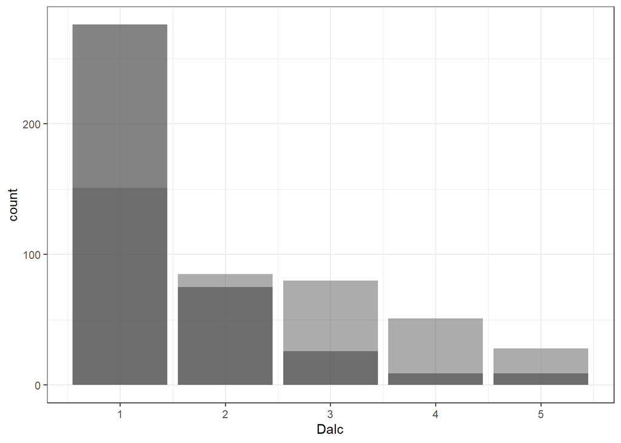

```r
ggplot(data=students,mapping=aes(x=Dalc)) +
  geom_bar(alpha = 0.75) +
  geom_bar(aes(x=Walc),alpha=0.5) +
  theme_bw()
```

It looks like there is quite a difference between the workday vs weekend alcohol consumption.

### Independent Variables

The following code provides a summary of the variables, as well as a bar plot comparing the distributions of different categories and how many lie in each category of alcohol consumption.

higher - Describes whether the student intends to pursue higher education or not (yes or no) This variable could be significant, because we could predict that students who intend to pursue higher education are less likely to drink

```r
table(students$higher)
```

```
##
##  no yes
##  20 375
```

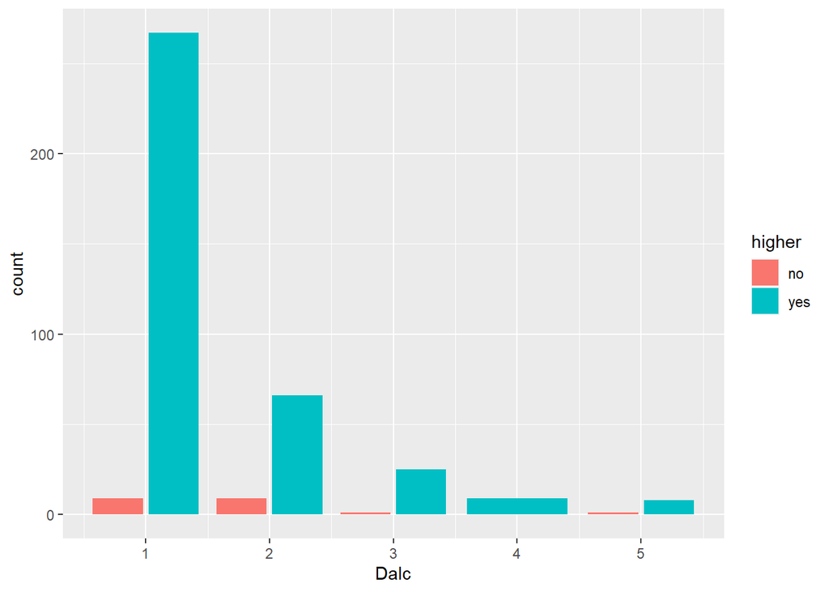

```r
ggplot(data=students, mapping=aes(x=Dalc)) +
  geom_bar(aes(fill=higher),position="dodge2")
```

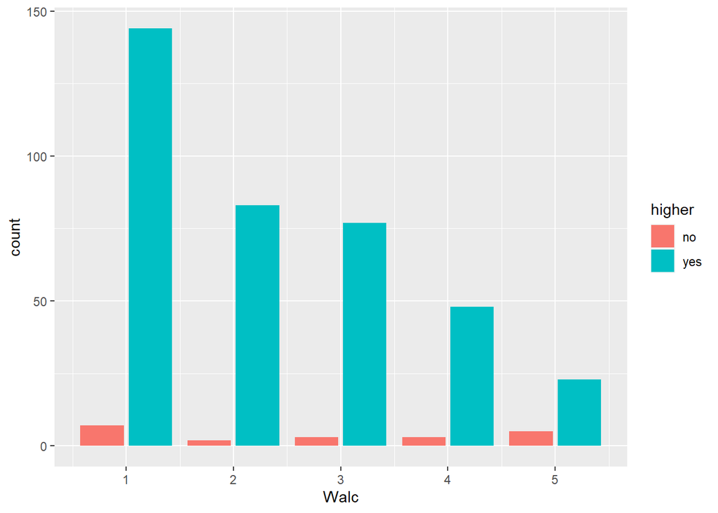

```r
ggplot(data=students, mapping=aes(x=Walc)) +
  geom_bar(aes(fill=higher),position="dodge2")
```

internet - Describes whether the student has internet access at home (yes or no)

```r
table(students$internet)
```

```
##
##  no yes
##  66 329
```

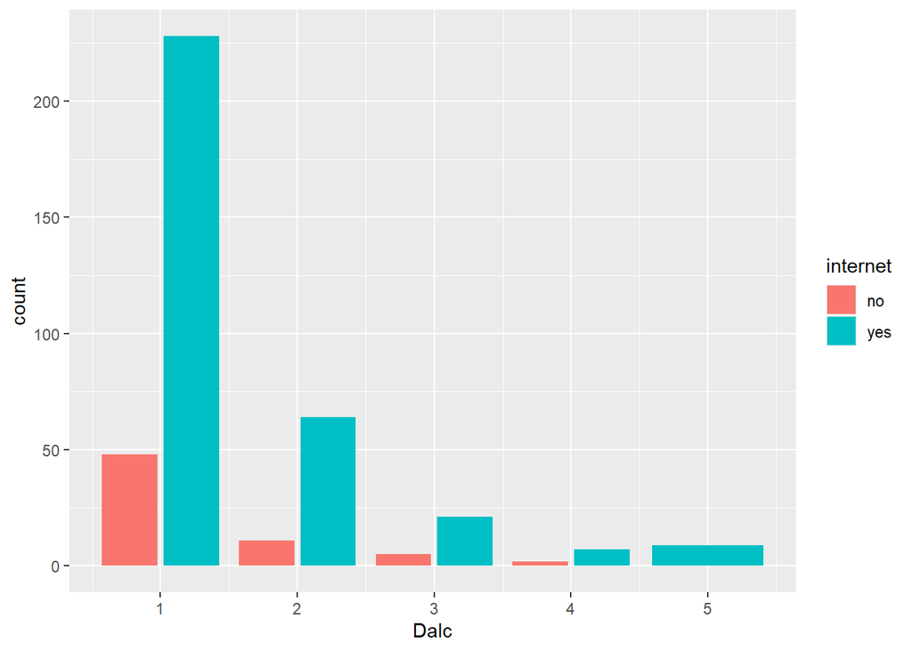

```r
ggplot(data=students, mapping=aes(x=Dalc)) +
  geom_bar(aes(fill=internet),position="dodge2")
```

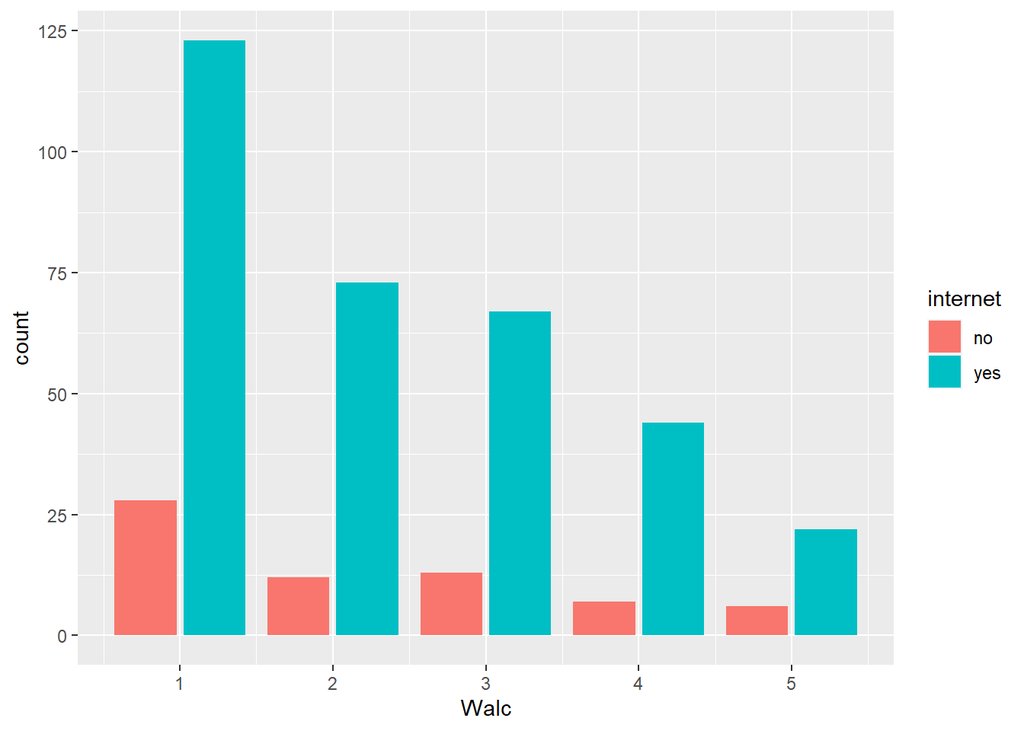

```r
ggplot(data=students, mapping=aes(x=Walc)) +
  geom_bar(aes(fill=internet),position="dodge2")
```

romantic - Describes whether the student is in a romantic relationship or not (yes or no)

```r
table(students$romantic)
```

```
##
##  no yes
## 263 132
```

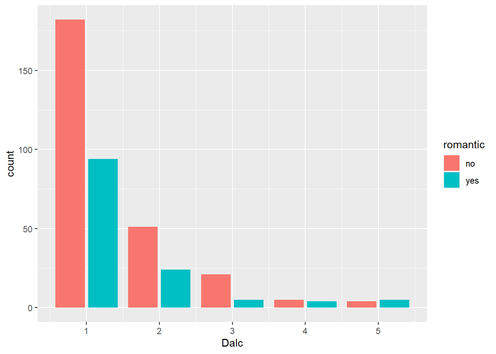

```r
ggplot(data=students, mapping=aes(x=Dalc)) +
  geom_bar(aes(fill=romantic),position="dodge2")
```

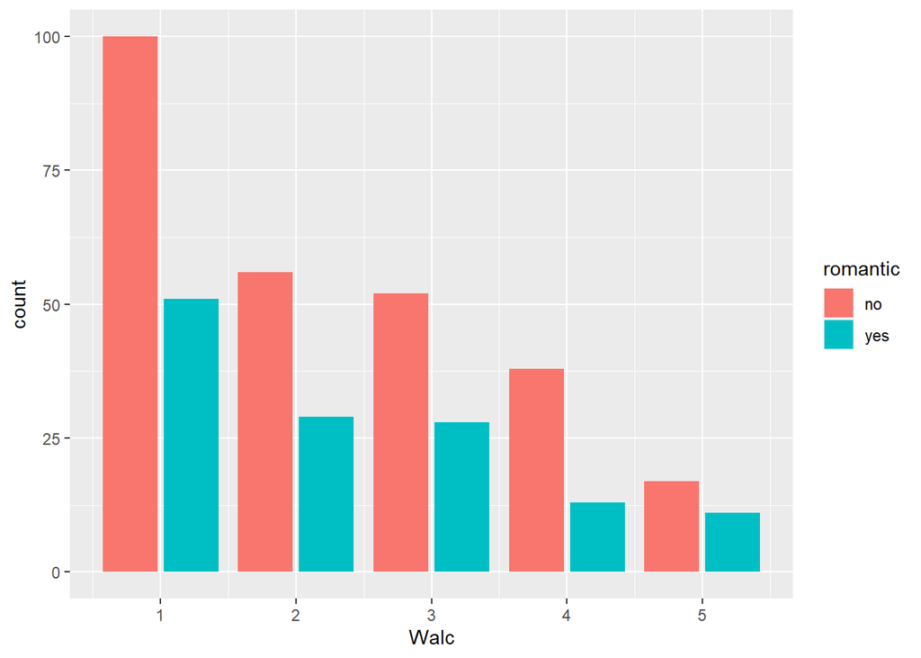

```r
ggplot(data=students, mapping=aes(x=Walc)) +
  geom_bar(aes(fill=romantic),position="dodge2")
```

famrel - Describes the quality of the student’s family relationship (scale of 1 to 5)

```r
table(students$famrel)
```

```
##
##   1   2   3   4   5
##   8  18  68 195 106
```

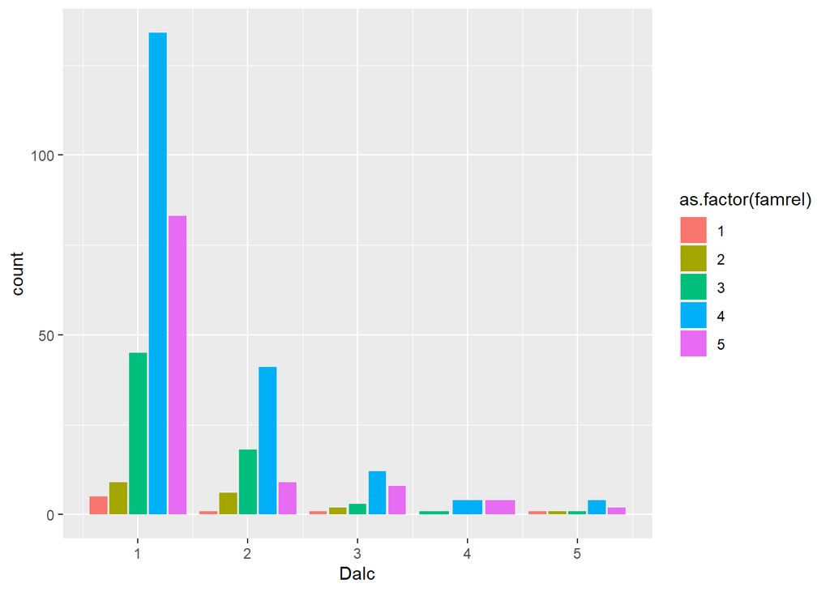

```r
ggplot(data=students, mapping=aes(x=Dalc)) +
  geom_bar(aes(fill=as.factor(famrel)),position="dodge2")
```

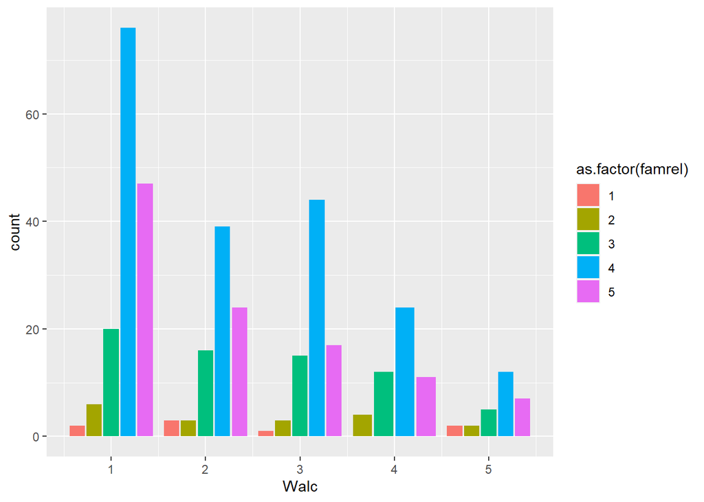

```r
ggplot(data=students, mapping=aes(x=Walc)) +
  geom_bar(aes(fill=as.factor(famrel)),position="dodge2")
```

freetime - Describes how much free time the student has (scale of 1 to 5)

```r
table(students$freetime)
```

```
##
##   1   2   3   4   5
##  19  64 157 115  40
```

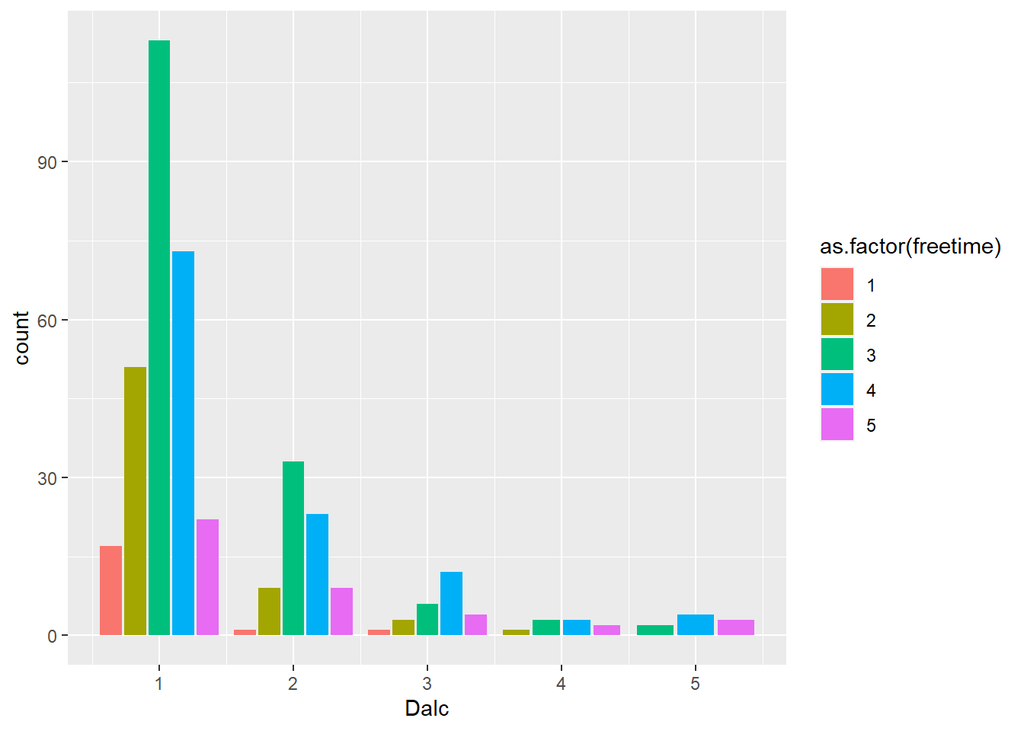

```r
ggplot(data=students, mapping=aes(x=Dalc)) +
  geom_bar(aes(fill=as.factor(freetime)),position="dodge2")
```

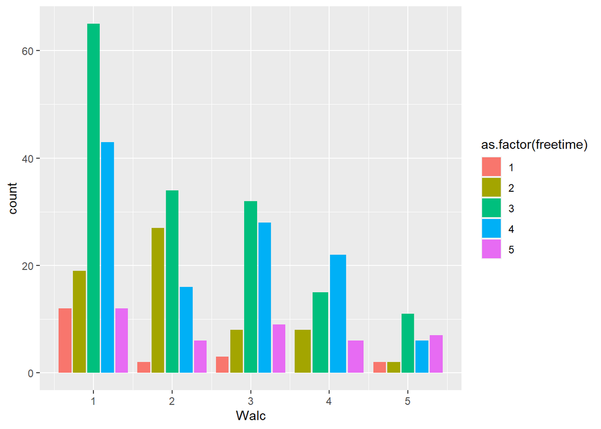

```r
ggplot(data=students, mapping=aes(x=Walc)) +
  geom_bar(aes(fill=as.factor(freetime)),position="dodge2")
```